# Introduction to R

Ravi K Patel

Jan 12, 2021

### Overview

- **Background on R**
- **Basic syntax**
  - Code statement
    - Comments
    - Operation
  - Variable
  - Assignment operator
- **Data types**
  - Numeric
  - Character
  - Logical (boolean)
- **Operators**
  - Arithmetic
  - Relational
  - Logical
- **Control statements**
  - if..else
  - for
- **Data structures**
  - Vector
  - Factor
  - Matrix
  - Lists
  - Data frame
- **File reading-writing**
  - `setwd()`
- **R functions**

### Basic syntax

#### *Code statement*

Broadly speaking, the code statement can take two forms:

1. a comment (a text in English to explain the code): R makes use of the # sign to add comments, so that you and others can understand what the R code is about. Just like Twitter! Comments are not run as R code, so they will not influence your result. Using too many comments is never too much.
2. operations: Operations can take many shapes and forms. They can be as simple as addition of 2 and 3 or can be very complex. We will look at a larger variety of operations in this lecture. Hang on, hold tight!

```r
# This is a comment.


# Operation
5 + 7
```

```
## [1] 12
```

```r
# I have 5 apples and 7 oranges. I have 5 + 7 fruits.
5 + 7
```

```
## [1] 12
```

#### *Variables and the assignment operator ( “<-” or “=”)*

Like we saw above, when we performed the “addition” operation, the result of the operation was printed by R and was removed from the memory. If we want to use the result of the operation later in the code, we need to store it into the computer memory. We can do so by creating a variable and storing the result into the variable. When we do this, the computer reserves a physical location on the computer memory and stores the result of the operation at that location, which we can access later using the variable name.

There are some rules and some good-practices when it comes to creating variable names.

Rules:

1. The variable name must start with a letter and can contain number, letter, underscore(’_‘) and period(’.’).
2. Special characters such as ‘#’, ‘&’, etc., along with White space (tabs, space) are not allowed in a variable name.
3. Reserved words or keywords are not allowed to be defined as a variable name.

Good-practices:

1. Use a meaningful name for variables.
2. Use underscores and/or periods to create more readable variable names.

There is also a nice [blog](http://adv-r.had.co.nz/Style.html) on good practices for writing a neat code.

```r
# Store number of apples in a variable
apples <- 5

# Store number of oranges in a variable
oranges <- 7

# Total number of fruits
fruits <- apples + oranges
```

```r
# Printing the value of variables
print("Total number of apples: ")
print(apples)
print("Total number of oranges: ")
print(oranges)
print("Total number of fruits: ")
print(fruits)
```

```
## [1] "Total number of apples: "
## [1] 5
## [1] "Total number of oranges: "
## [1] 7
## [1] "Total number of fruits: "
## [1] 12
```

### Data types

- Numeric
- Character
- Logical (boolean)

In the code above, we stored the numeric type of data in the variables. Let’s look at the three most useful data types that we can store in an R variable. Read about the full list of data types [here](https://www.tutorialspoint.com/r/r_data_types.htm)

1. numeric (integer and float values)
2. character (text / string of characters)
3. logical (boolean; TRUE/FALSE)

```r
# Create a variable of type "numeric"
my_numeric <- 2 + 3

# Create a variable of type "character"
my_character <- "ATGCCAGATAGAC"

# Create a variable of type "logical"
my_logical <- TRUE
```

Let’s determine the class of each variable using `class()` function

```r
# Check the class of a variable
class(my_numeric)
```

```
## [1] "numeric"
```

```r
class(my_character)
```

```
## [1] "character"
```

```r
class(my_logical)
```

```
## [1] "logical"
```

##### **Exercise**

```r
# Create one numeric variable, one character variable and one logical variable and print them.
```

### Operators

#### *Arithmetic:*

Now that we are familiar with the basic syntax of the code statement and the most useful data types, let’s dive right into the more fun part. Below is a list of operations and the corresponding operator codes for numerical variables.

- Addition: `+`
- Subtraction: `-`
- Multiplication: `*`
- Division: `/`
- Exponentiation: `^`
- Modulo: `%%`

```r
########## Syntax ##########
# Binary operators:
#   variable_1 `operator` variable_2
############################

# Addition: add 2 and 3
val_add <- 2 + 3

val_add
```

```
## [1] 5
```

```r
# Subtraction
val_sub <- 10 - 5

val_sub
```

```
## [1] 5
```

```r
# Multiplication
val_multiply <- 12 * 5

val_multiply
```

```
## [1] 60
```

```r
# Division
val_divide <- 10 / 3

val_divide
```

```
## [1] 3.333333
```

```r
# Exponentiation
val_power <- 2 ^ 3

val_power
```

```
## [1] 8
```

```r
# Modulo
val_remainder <- 10 %% 3

val_remainder
```

```
## [1] 1
```

##### **Exercise**

```r
# Calculate and print percentages of apples and oranges.
apples <- 5
oranges <- 7
fruits <- apples + oranges
```

#### *Relational:*

Once we store the different type of values in to variables, we may next want to compare two values with each other. Below is a list of operations and the corresponding operator codes for comparing two numerical, character or logical variables. The relational operation will come very handy when we want to apply different “if-else” conditions in our code.

- Greater than: `>`
- Less than: `<`
- Greater or equal: `>=`
- Less or equal: `<=`
- Equal: `==`
- Not-equal: `!=`

```r
########## Syntax ##########
# Binary operators:
#   variable_1 `operator` variable_2
############################

# Is the number of fruits larger than 20?
fruits > 20
```

```
## [1] FALSE
```

```r
# Do we have less apples than oranges in the basket?
apples < oranges
```

```
## [1] TRUE
```

```r
# Is the numeric 6 same as "six"?
6 == "six"
```

```
## [1] FALSE
```

##### **Exercise**

```r
# Exercise 1: Are "ten" and "Ten" the same?




# Exercise 2: Test each relational operator and find out the data type of their output.
```

#### *Logical:*

Above we saw ways make a single comparison at a time, for example, is the number of fruits larger than 20. We can combine and test multiple conditions together to build complex conditions. For example, is the number of fruits larger than 20 and smaller than 50. Below is a list of operations and the corresponding operator codes for combining multiple conditions.

- And: `&`
- Or: `|`
- Not: `!`

```r
########## Syntax ##########
# Binary operators:
#   variable_1 `operator` variable_2

# Unary operator:
#   `operator` variable_1
############################

# Let's say we added 3 bananas and 10 strawberries in the basket.
bananas <- 3
strawberries <- 10
fruits <- apples + oranges + bananas + strawberries


# And operator
# Which fruits have more than 4 and less than 9 counts?
apples > 4 & apples < 9
```

```
## [1] TRUE
```

```r
oranges > 4 & oranges < 9
```

```
## [1] TRUE
```

```r
bananas > 4 & bananas < 9
```

```
## [1] FALSE
```

```r
strawberries > 4 & strawberries < 9
```

```
## [1] FALSE
```

```r
# Or
# Which fruits have 3 counts or more than or equal to 7 counts?
apples == 3 | apples >= 7
```

```
## [1] FALSE
```

```r
# Not
# Which fruits DON'T have 3 counts or more than or equal to 7 counts?
! (apples == 3 | apples >= 7)
```

```
## [1] TRUE
```

**[Read more: operators](https://www.tutorialspoint.com/r/r_operators.htm)**

### Data structures

So far we looked at atomic variables, the variables that can store only one value at a time. It can quickly become a massive inconvenience to manage and maintain the atomic variables as the number of values start to increase. To solve this problem, various complex data structures are developed for an efficient storage and access of large amount of data. We will look at all of them one-by-one in this tutorial with examples.

#### *Vectors*

Vector is basically a set of multiple atomic variables of the **same data type** arranged in some order. A vector is created by supplying a set of values or variables to the `c()` function. The vector can store any of the above mentioned data types. The type of the data stored in a vector can be inspected using the `class()` function. Another important property of the vector is the length, i.e., the number of element in the vector, which can be obtained using the `length()` function.

```r
########## Syntax ##########
# my_vec <- c(5, 7, 3, 10)
############################


#### Creating a vector

# Create a numeric vector
my_numeric_vector <- c(20, 100, 30, 25, 60)


# Create a character vector
my_character_vector <- c("Monday", "Tuesday", "Wednesday", "Thursday", "Friday", "Saturday", "Sunday")


# Print elements of vectors
print(my_numeric_vector)
```

```
## [1]  20 100  30  25  60
```

```r
print(my_character_vector)
```

```
## [1] "Monday"    "Tuesday"   "Wednesday" "Thursday"  "Friday"    "Saturday"
## [7] "Sunday"
```

```r
# Print length of vectors
length(my_numeric_vector)
```

```
## [1] 5
```

```r
length(my_character_vector)
```

```
## [1] 7
```

```r
# Assess the structure of vectors
str(my_numeric_vector)
```

```
##  num [1:5] 20 100 30 25 60
```

```r
str(my_character_vector)
```

```
##  chr [1:7] "Monday" "Tuesday" "Wednesday" "Thursday" "Friday" "Saturday" ...
```

```r
# Using a sequence to create a vector
# Colon ":" operator
1:10
```

```
##  [1]  1  2  3  4  5  6  7  8  9 10
```

```r
#### Creating a named vector
########## Syntax ##########
# my_vec <- c("name1" = 5, "name2" = 7, "name3" = 3, "name4" = 10)
############################

# Let's first create a unnamed fruit_basket vector containing fruit counts
fruit_basket <- c(apples, oranges, bananas, strawberries)
print(fruit_basket)
```

```
## [1]  5  7  3 10
```

```r
# Create a fruit_basket vector containing fruit names and fruit counts
# Remember, the "=" sign here can not be replaced by "<-"
fruit_basket <- c("Apple" = apples, "Orange" = oranges, "Banana" = bananas, "Strawberry" = strawberries)
print(fruit_basket)
```

```
##      Apple     Orange     Banana Strawberry
##          5          7          3         10
```

```r
# Assess the structure of the vector
str(fruit_basket)
```

```
##  Named num [1:4] 5 7 3 10
##  - attr(*, "names")= chr [1:4] "Apple" "Orange" "Banana" "Strawberry"
```

```r
#### Selecting elements of a vector
########## Syntax ##########
# my_vec[index(s)]
#    OR
# my_vec[name(s)]
############################

# Select orange counts
fruit_basket[2]
```

```
## Orange
##      7
```

```r
#    OR
fruit_basket["Orange"]
```

```
## Orange
##      7
```

```r
# Select apple and strawberry counts.
fruit_basket[c(1, 4)]
```

```
##      Apple Strawberry
##          5         10
```

```r
# Select apple, banana and strawberry counts.
fruit_basket[c(1, 3, 4)]
```

```
##      Apple     Banana Strawberry
##          5          3         10
```

```r
#### Modifying elements of a vector

# Change the count of bananas from 3 to 20
fruit_basket["Banana"] <- 20
print(fruit_basket)
```

```
##      Apple     Orange     Banana Strawberry
##          5          7         20         10
```

```r
# Add two extra values to the fruit_basket vector
fruit_basket <- c( fruit_basket, c( "Plum" = 10, "Peach" = 13 ) )
print(fruit_basket)
```

```
##      Apple     Orange     Banana Strawberry       Plum      Peach
##          5          7         20         10         10         13
```

```r
# Deleting specific elements: delete 2nd, 5th and 6th elements from my_character_vector
print(my_character_vector)
```

```
## [1] "Monday"    "Tuesday"   "Wednesday" "Thursday"  "Friday"    "Saturday"
## [7] "Sunday"
```

```r
my_character_vector <- my_character_vector[ -c(2,5,6) ]

print(my_character_vector)
```

```
## [1] "Monday"    "Wednesday" "Thursday"  "Sunday"
```

```r
#### Numeric vector operations

# Add 10 to every element of a vector
fruit_basket + 10
```

```
##      Apple     Orange     Banana Strawberry       Plum      Peach
##         15         17         30         20         20         23
```

```r
# Find a length of a vector
length(fruit_basket)
```

```
## [1] 6
```

```r
# Count the total number of fruits in the fruit basket.
sum(fruit_basket)
```

```
## [1] 65
```

```r
# Calculate the mean number of fruits in the basket
mean(fruit_basket)
```

```
## [1] 10.83333
```

##### **Exercise**

```r
# Exercise 1: Create and print a named vector of day-counts in the first 5 months: January, February, March, April and May (i.e., 31; 28; 31; 30; 31).




# Exercise 2: Select and print the number of days in March




# Exercise 3: Find total number of days in the vector using "+" operator.
```

### Control statements

Before we dive into other data structures, let’s first look at the control statement, the code statements that helps redirect the flow of execution of a series of R operations. Basically, control statements allow you to put some “logic” into your R code, rather than just always executing the same R code every time. Control statements allow you to respond to inputs or to features of the data and execute different R expressions accordingly.

#### *`if..else`*

The `if..else` allows for testing conditions and acting based on the condition outcome. For example, if there are more apples than oranges, perform one set of operations, otherwise perform a different set of operations.

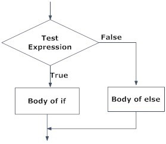

Figure: operation of `if..else` statement

```r
########## Syntax ##########
# if (test_expression) {
#   statement
# } else {
#   statement
# }
############################

# Do we have less apples than oranges in the basket?
# apples < oranges
# [1] TRUE

# Test and print if we have less apples than oranges.
if(apples < oranges) {
  print("Fruit basket has less apples than oranges")
} else {
  print("Fruit basket more apples than oranges")
}
```

```
## [1] "Fruit basket has less apples than oranges"
```

#### *`for` loop*

The `for` loop executes a set of operations for a fixed number of times, therefore it is called a loop. For example, loop through every element in the fruit_basket vector and print the fruit counts for each fruit with a well formatted message.

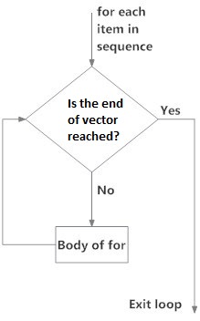

Figure: operation of `for` statement

```r
########## Syntax ##########
# for( i in vector ) {
#   statement
# }
############################


# Create a numeric vector, iterate through each element and print them.
my_numeric_vec <- c(12, 54, 65, 16, 83, 79, 99, 47, 81, 18)

# for loop
for( i in my_numeric_vec ) {
  # statement
  print(i)

}
```

```
## [1] 12
## [1] 54
## [1] 65
## [1] 16
## [1] 83
## [1] 79
## [1] 99
## [1] 47
## [1] 81
## [1] 18
```

```r
# Create a character vector of days of a week, iterate through each element and print every other element in the following form:
# The value of element # 1 is Mon
# The value of element # 3 is Wed
# ....
# The value of element # 7 is Sun


# A vector of days of a week
my_character_vec <- c("Mon", "Tue", "Wed", "Thu", "Fri", "Sat", "Sun")

# A variable to keep count of iterations
count <- 0

for( day in my_character_vec) {

  count <- count + 1

  if( count %% 2 == 1 ) {

    print_message <- paste("The value of element #", count, "is", day)
    print(print_message)

  }

}
```

```
## [1] "The value of element # 1 is Mon"
## [1] "The value of element # 3 is Wed"
## [1] "The value of element # 5 is Fri"
## [1] "The value of element # 7 is Sun"
```

##### **Exercise**

```r
# Exercise 1: Iterate through the elements of the following character vector and print each element.
planet_names <- c("Mercury", "Venus", "Earth", "Mars", "Jupiter", "Saturn", "Uranus", "Neptune")










# Exercise 2:
# Remember the following code where we had to manually type one statement per element to find fruits that had
# more than 4 and less than 9 counts? Remember how inefficient the code was and how non-user-friendly the output was?
    # Which fruits have more than 4 and less than 9 counts?
    # apples > 4 & apples < 9
    # oranges > 4 & oranges < 9
    # bananas > 4 & bananas < 9
    # strawberries > 4 & strawberries < 9

# Let's add more fruits to the fruit basket and write a code that iterates through each element of the fruit_basket vector and prints if more quantities should be bought if the fruit count drops below 10.

# Creating a fruit_basket vector.
fruit_basket <- c(apples = 15, bananas = 10, peaches = 4, oranges = 7, strawberries = 20, kiwis = 9, mangoes = 1, plums = 6)










# Exercise 3
# Use selection by comparison (e.g. fruit_basket < 10) to select fruits that are below 10 counts.
```

### Data structures

#### *Factors*

Factor is a statistical data structure that is designed specifically for storing categorical variables, variables that have a fixed and known set of possible values, e.g. gender of surveyed individuals. Three major advantages of using factors over vectors are:

1. the factor prevents typos;
2. the factor allows sorting of elements in a meaningful way; and
3. factors make it very easy to modify the existing values.

The factors are created by supplying a vector of individual categorical values and a vector of levels - all possible values the factor can hold - to the function `factor()`. If you omit the levels, they’ll be taken from the data in alphabetical order.

```r
########## Syntax ##########
# my_factor <- factor( c("M","F","F","M","F"), levels = c("F","M") )
############################


#### Creating factors

## Create a factor for storing marital status of 10 sampled individuals for your research study.
# Create a vector for levels
marital_status_levels <- c("married", "divorced", "single", "separated")

# Create a vector of individual values
marital_status_values <- c("single", "single", "separated", "married", "single", "married", "separated", "divorced", "single", "married")

# Create a factor using factor()
# Remember, the "=" sign here can not be replaced by "<-"
marital_status_factor <- factor( marital_status_values, levels = marital_status_levels  )

# Print the factor
# Notice the orders of levels and values.
print(marital_status_factor)
```

```
##  [1] single    single    separated married   single    married   separated
##  [8] divorced  single    married
## Levels: married divorced single separated
```

```r
# Print the levels alone.
levels(marital_status_factor)
```

```
## [1] "married"   "divorced"  "single"    "separated"
```

```r
# Use class() to determine the class of the data structure
class(marital_status_factor)
```

```
## [1] "factor"
```

```r
## 1) the factor prevents typos
## Add two new entries in the factor

# Add first entry.
marital_status_factor[11] <- "married"
print(marital_status_factor)
```

```
##  [1] single    single    separated married   single    married   separated
##  [8] divorced  single    married   married
## Levels: married divorced single separated
```

```r
# Add a second entry that has a typo
marital_status_factor[12] <- "marriied"
print(marital_status_factor)
```

```
##  [1] single    single    separated married   single    married   separated
##  [8] divorced  single    married   married   <NA>
## Levels: married divorced single separated
```

```r
## 2) the factor allows sorting of elements in a meaningful way
## Sort the factor in meaningful ways using sort()

# Notice that the function sort() sorts the elements of the vector marital_status_values in an alphabetical order.
sort(marital_status_values)
```

```
##  [1] "divorced"  "married"   "married"   "married"   "separated" "separated"
##  [7] "single"    "single"    "single"    "single"
```

```r
# Notice that the function sort() sorts the elements of the factor marital_status_factor in the order of the levels.
sort(marital_status_factor)
```

```
##  [1] married   married   married   married   divorced  single    single
##  [8] single    single    separated separated
## Levels: married divorced single separated
```

```r
# Sort values of the factor in the following order: single, married, separated, divorced
marital_status_factor <- factor( marital_status_values, levels = c("single", "married", "separated", "divorced")  )

# Notice the orders of levels and values
print(marital_status_factor)
```

```
##  [1] single    single    separated married   single    married   separated
##  [8] divorced  single    married
## Levels: single married separated divorced
```

```r
# Notice the orders of levels and values
sort(marital_status_factor)
```

```
##  [1] single    single    single    single    married   married   married
##  [8] separated separated divorced
## Levels: single married separated divorced
```

```r
## 3) factors make it very easy to modify the existing values
## Change all "married" values to "MARRIED"

# First, get the levels
marital_status_levels <- levels(marital_status_factor)

# Change the second value to "MARRIED"
marital_status_levels[2] <- "MARRIED"

# Assign these modified levels to marital_status_factor
levels(marital_status_factor) <- marital_status_levels

print(marital_status_factor)
```

```
##  [1] single    single    separated MARRIED   single    MARRIED   separated
##  [8] divorced  single    MARRIED
## Levels: single MARRIED separated divorced
```

```r
#### Selecting specific elements from the factor

# Select the 4th element
marital_status_factor[4]
```

```
## [1] MARRIED
## Levels: single MARRIED separated divorced
```

```r
# Select the 2nd, 5th and 6th elements
marital_status_factor[c(2,5,6)]
```

```
## [1] single  single  MARRIED
## Levels: single MARRIED separated divorced
```

```r
# Select the 1st, 3rd, 7th, 9th and 10th elements
marital_status_factor[c(T,F,T,F,F,F,T,F,T,T)]
```

```
## [1] single    separated separated single    MARRIED
## Levels: single MARRIED separated divorced
```

```r
#### Modifying elements of a factor

## Removing specific elements
marital_status_factor[-c(3,6,7)]
```

```
## [1] single   single   MARRIED  single   divorced single   MARRIED
## Levels: single MARRIED separated divorced
```

##### **Exercise**

```r
# Exercise 1: Create a factor for storing gender of 10 surveyed individuals using the following vector of levels.
# Vector of levels
gender_levels <- c("f","m")

# Write a code to create the factor



# Write a code to change all "f" values to "Female" and all "m" values to "Male"
```